# Transformar datos

## Tidyverse

Muchas veces los datos que importamos ya están listos para ser explorados y analizados. Otras veces precisan ser manipulados previamente para ello. En estos casos se parte de un dataset “crudo” y se transforma hacia un dataset “analítico”.

`tidyr` y `dplyr` integran parte de la colección de paquetes de `tidyverse` y facilitan la manipulación de los data frames

[figure not shown]

El caracter principal para utilizar ambas librerías es `%>%` , *pipe* (de tubería), atajo: `ctrl+shift+m`

Los `%>%` toman el set de datos a su izquierda, y los transforman mediante los comandos a su derecha, en los cuales los elementos de la izquierda están implícitos. En otros términos:

$f(x,y)$ es equivalente a $x$ %>% $f(.,y)$

### Ejemplo en el uso de ´%>%´:

```r
x <- c(1, 2, 3, 4)
x %>% sum %>% sqrt
```

Su equivalente sería:

```r
sqrt(sum(x))
```

## Librería dplyr

Algunas funciones de `dplyr`:

`select` `filter` `mutate` `arrange` `summarise`

### select

Selecciona variables de un dataframe.

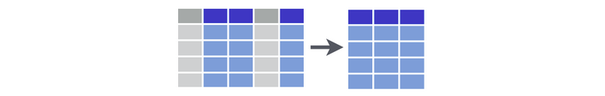

### filter

se utiliza para crear un subconjunto de un marco de datos, conservando todas las filas que cumplen las condiciones establecidas.

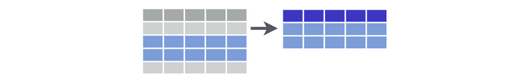

### mutate

Permite agregar una variable a la tabla, que puede ser el resultado de operaciones sobre otras variables de la misma tabla. Se debe indicar el nombre que tomará esta variable.

En caso de especificar el nombre de una columna existente, el resultado de la operación realizada “sobre-escribirá” la información de la columna con dicho nombre.

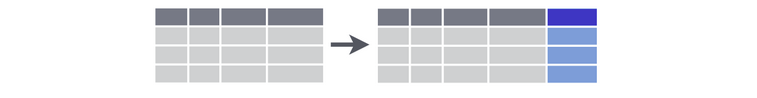

### arrange

Ordena crecientemente de acuerdo a la columna que le indiquemos. Utilizar `desc` para orden decrescente.

### summarise

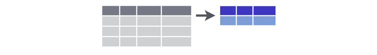

Esta función es generalmente acompañada por la función `group_by`, la cual permite realizar cálculo de un grupo de observaciones del dataframe, agrupando por niveles de un determinado factor.

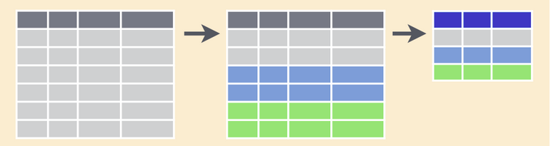